# Simple Central

- Introduction
- Hardware Prerequisites
- Software Prerequisites
- Usage
  - GATT Read
  - GATT Write
  - Start RSSI Reading
  - Connection Update
  - Set Conn PHY Preference
  - Disconnect

## Introduction

The `simple_central` project implements a simple Bluetooth low energy central device with GATT client functionality. By default, the `simple_central` application is configured to filter and connect to peripheral devices with the TI Simple Profile UUID, such as devices with the `simple_peripheral` project. To modify this behavior, set `DEFAULT_DEV_DISC_BY_SVC_UUID` to `FALSE` in `simple_central.c`.

This project has the following app configurations available:

| App Build Configuration | Description |
| --- | --- |
| FlashROM_Release (default) | All TI-RTOS debug features disabled but application-logging to UART remains enabled. The application uses the config file `ble_release.cfg` and the defines are in `<app name>_FlashROM_Release.opt`. |
| FlashROM_Debug | All TI-RTOS debug features enabled. The application uses the config file `ble_debug.cfg` and the defines are in `<app name>_FlashROM_Debug.opt`. |

All application configurations use the stack library configuration, FlashROM_Library. This build configuration will yield additional flash footprint optimizations by the linker since the application and stack can share contiguous flash pages. This configuration is further discussed in the Stack Library Configuration section of the **BLE5-Stack User’s Guide** provided in the SDK.

## Hardware Prerequisites

The default Simple Central board configuration uses the device’s LaunchPad development kit. This hardware configuration is shown in the below image:

[figure not shown]

For custom hardware, see the Running the SDK on Custom Boards section of the **BLE5-Stack User’s Guide**.

## Software Prerequisites

For information on what versions of Code Composer Studio and IAR Embedded Workbench to use, see the Release Notes file provided in the SDK. For information on how to import this project into your IDE workspace and build/run, please refer to the device’s Platform section in the **BLE5-Stack User’s Guide**.

## Usage

This application uses the UART peripheral to provide an interface for the application. The UART is only used for display messages.

This document will use a terminal program (Tera Term, PuTTY, etc.) to serve as the display for the output of the LaunchPad. Note that any other serial terminal can be used. The following default parameters are used for the UART peripheral for display:

| UART Param | Default Values |
| --- | --- |
| Baud Rate | 115200 |
| Data length | 8 bits |
| Parity | None |
| Stop bits | 1 bit |
| Flow Control | None |

Once the Simple Central sample application starts, the output to the terminal will report its address and that it is initialized and ready to begin discovery, as shown below. On the menu, you can use the left button (BTN-1) to move to the next option and the right button (BTN-2) to select an item:

[figure not shown]

The first option can be selected to set the Scanning PHY. For more information on PHY refer to the PHY section in the **BLE5-Stack User’s Guide**.

[figure not shown]

The second option can be selected to begin discovering devices that are broadcasting BLE advertisements. This will report the number of discovered devices. Select `Connect to` to view the list of devices and use the left button (BTN-1) to go through the available devices:

[figure not shown]

When you have found the device that you are trying to connect to, press the right button to connect. This will display information such as the connection timeout and the address of the connected peripheral device. Once connected select `Work with` and select the connected device.

[figure not shown]

It will now present you with 6 options. These options will be described in the following sections:

- GATT Read
- GATT Write
- Start RSSI Reading
- Connection Update
- Set Conn PHY Preference
- Disconnect

It is also possible to browse to and select “Upper Menu” to return to the main menu.

### Option: GATT Read

This option is used to send read requests to the peripheral device. Pressing the right button once will send a read request to the peripheral device and will print the returned value of the characteristic. Note that this characteristic can be written to with the `GATT Write` option:

[figure not shown]

### Option: GATT Write

This option is used to write predetermined values (0x00, 0x55, 0xAA, etc.) to the device’s characteristic. Note that this characteristic can be read from with the `GATT Read` option:

[figure not shown]

### Option: Toggle Read RSSI

This option is used to get the RSSI (signal strength) of the connected peripheral device. Selecting this option will toggle RSSI reads on and off. When it is on, the RSSI value will be printed. The value will continue to be updated as the RSSI changes:

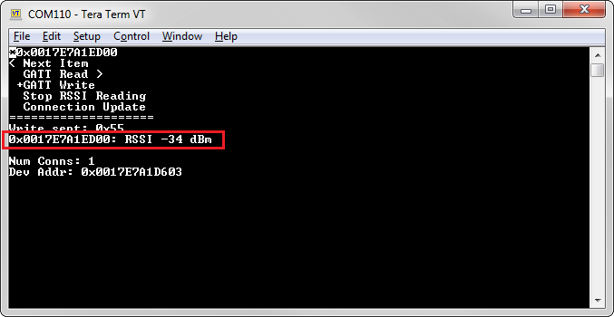

### Option: Connection Update

This option updates the connection parameters based on the values set by the following constants in `simple_central.c`:

- DEFAULT_UPDATE_MIN_CONN_INTERVAL
- DEFAULT_UPDATE_MAX_CONN_INTERVAL
- DEFAULT_UPDATE_SLAVE_LATENCY
- DEFAULT_UPDATE_CONN_TIMEOUT

The update was successful if it states that it has been “Updated” and displays the new connection timeout value.

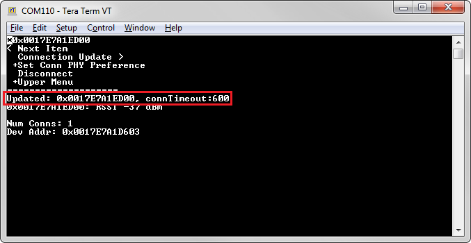

### Option: Set Conn PHY Preference

This option is used to select the PHY preference for the current connection. If the PHY preference is changed to include a “faster” PHY than before, `simple_central` will attempt a PHY change. You can choose from the following options:

- 1 Mbps
- 2 Mbps
- 1 & 2 Mbps
- Coded
- 1 & 2 Mbps, & Coded

For more information on PHY refer to the PHY section in the **BLE5-Stack User’s Guide**. The following shows a successful update to Coded PHY:

[figure not shown]

### Option: Disconnect

This option will send a link termination request to terminate the connection with the connected device. The following shows a successful disconnection:

[figure not shown]

Note that this application also supports MTU exchanges. This is done automatically by the Simple Central device after a connection is formed with a peripheral device. A larger MTU can be negotiated by changing `MAX_PDU_SIZE`. More information on this can be found in the Configuring for Larger MTU Values section of the **BLE5-Stack User’s Guide**.

Also note that the application will automatically request pairing once the connection is established.